# Homework: finite precision arithmetic

# Problem 1

Figure out what the function `determine_precision` is trying to do and fill out the missing line.

```r
are_numerically_distinguishable <- function(value1, value2) {
  return(value1 != value2)
}

#' Finds the precision in R.
determine_precision <- function(init_upper_bound = 1) {
  curr_upper_bound <- init_upper_bound
  divider <- 2
  while (are_numerically_distinguishable(1, 1 + curr_upper_bound)) {
    curr_upper_bound <- curr_upper_bound / divider
  }
  return(list(
    lower_bd = curr_upper_bound,
    upper_bd = divider * curr_upper_bound
  ))
}

prec <- determine_precision()
print(sprintf(
  "The precision is between %.3g and %.3g.",
  prec$lower_bd, prec$upper_bd
))
```

```
[1] "The precision is between 1.11e-16 and 2.22e-16."
```

**Remark:** R does not have a native support for single-precision numbers.

# Problem 2

The following problem is inspired by Hofert (2020) (https://arxiv.org/abs/2003.08009). Draw a large number of random variables uniformly distributed in [0, 1]. In theory, no two random variables take the exact same value. In practice, however, there is small but positive probability of that happening because of finite precision in computer representation of real numbers. Count the number of duplicates in the generated pseudo random numbers. Does it agree with the theoretical expected value? If not, try coming up with possible explanations for the observed behavior (other than “Aki is an idiot — there must be a bug in his function”).

```r
#' Estimates the expected number of duplicates when drawing uniformly with replacement.
est_num_expected_duplicate <- function (n_draw, n_choice) {
  return(n_draw * (n_draw - 1) / n_choice) # First-order approx
}

n_unique_double <- 2^53 # Number of unique machine-representable values in [0, 1].
n_draw <- 10^6

est_num_expected_duplicate(n_draw, n_unique_double)
```

```
[1] 0.0001110222
```

# Problem 3

You have learned in the class that the centered difference $\frac{f(x + \Delta x) - f(x - \Delta x)}{2 \Delta x}$ approximates the derivative $f'(x)$ up to an $O(\Delta x^2)$ error. To numerically verify this, we design the following experiment using a log of logistic function (i.e. $f(x) = \log\{ \exp(x) / (1 + \exp(x)) \}$) as an example. We evaluate its derivative using an analytical formula and compare it to the centered difference approximations as $\Delta x$ varies from $2^{-1}$ to $2^{-52}$. Plot the relative error in a log-log scale. What do you expect the slope of the plotted line to be?

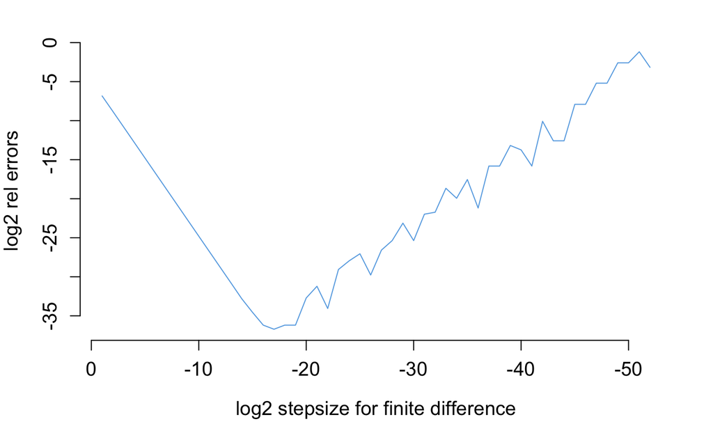

```r
#' Approximate derivative via centered-difference approximation
approximate_deriv <- function(func, x, dx) {
  return( (func(x+dx)-func(x-dx))/(2*dx) )
}

log_logistic_func <- function(x) {
  return( log(exp(x)/(1+exp(x))) )
}

log_logistic_deriv <- function(x) {
  return( 1/(1+exp(x)) )
}

# Calculate and plot the relative errors of finite difference approximations
set.seed(615)
x <- rnorm(1)

log2_dx <- - seq(1, 52)
numerical_deriv <- sapply(
  2^log2_dx, function(dx) approximate_deriv(log_logistic_func, x, dx)
)
analytical_deriv <- log_logistic_deriv(x)
rel_err <- abs(
  (analytical_deriv - numerical_deriv) / analytical_deriv
)

fontsize <- 1.2
plot(
  log2_dx, log2(rel_err),
  frame = FALSE, # Remove the ugly box
  col = jhu_color$spiritBlue,
  xlab = "log2 stepsize for finite difference",
  ylab = "log2 rel errors",
  xlim = rev(range(log2_dx)),
  cex.lab = fontsize,
  cex.axis = fontsize,
  type = 'l'
)
```

Does your output agree with what you expected? Explain the observed phenomenon.

At first the error decreases because when $\Delta x$ gets smaller, the approxixmation gets more accurate. Then the error increases again because the precision can not be guaranteed.

**Bonus question 1:** What is the slope in the “latter part” of your plotted line?

**Bonus question 2:** Implement a strategy to automatically choose a near-optimal $\Delta x$ for numerically approximating the derivative of a given function via centered difference. (Hint: first get a crude estimate of $f'(x)$ and refine it at the next iteration.)

# Problem 4

Many state-of-the-art algorithms for statistical inference rely on the gradient of a likelihood or loss function. These algorithms, however, will obviously fail if you supply a wrong gradient. (And you wouldn’t be the first one in history to have wasted your time looking for a bug in your algorithm implementation, only to realize that the bug was in your gradient calculation.) Taking a logistic regression with ridge penalty as a toy example, below we consider how we might ensure that our gradient calculation is correct.

```r
path_to_data <- file.path(path_to_script, 'data', 'InternetAd.RData')
  # Platform independent way of accessing a file
load(path_to_data)

n_obs <- InternetAd$x@Dim[1]
n_pred <- InternetAd$x@Dim[2]
```

**Remark:** The design matrix of `InternetAd` (taken from https://www.jstatsoft.org/article/view/v033i01) is representated as a sparse matrix in the compressed, sparse, column-oriented (CSC) form. We will discuss more about sparse matrices in future lectures and homework.

## Part 1

Use the provided `compute_logit_penalized_loglik` function and try running a gradient-free optimization algorithm from $\beta = (1, 1, ..., 1)$.

```r
compute_logit_penalized_loglik <- function(
    reg_coef, design_mat, n_success, n_trial=NULL, penalty = 1.
  ) {
  if (is.null(n_trial)) {
    # Assume binary outcome unless otherwise specified.
    n_trial <- rep(1, length(n_success))
  }
  logit_prob <- design_mat %*% reg_coef
  loglik <- sum(n_success * logit_prob - n_trial * log(1 + exp(logit_prob)))
  penalized_loglik <- loglik - .5 * penalty * sum(reg_coef^2)
  return(penalized_loglik)
}

compute_internet_ad_ploglik <- function(reg_coef) {
  return(compute_logit_penalized_loglik(reg_coef, InternetAd$x, InternetAd$y))
}


optim_result <- optim(
  par = rep(1, n_pred),
  fn = compute_internet_ad_ploglik,
  method = 'Nelder-Mead', # gradient-free algorithm
  control = list(fnscale = -1) # Maximize the function
)
```

```
Error in optim(par = rep(1, n_pred), fn = compute_internet_ad_ploglik,  :
  function cannot be evaluated at initial parameters
```

Oops, that didn’t work — figure out what went wrong. - *It returns “function cannot be evaluated at initial parameters”*.

After you figured it out, don’t worry about fixing it but try starting the optimization from $\beta = (0, 0, ..., 0)$. It should at least run now. - *Yes*.

```r
optim_result <- optim(
  par = rep(0, n_pred),
  fn = compute_internet_ad_ploglik,
  method = 'Nelder-Mead', # gradient-free algorithm
  control = list(fnscale = -1) # Maximize the function
)

optim_result$convergence
```

```
[1] 1
```

Write a code to call `warning` and let a user know otherwise.

```r
# Fill in --- let a user know if the algorithm converged or not
result.0 <- tryCatch(
  {
    optim_result <- optim(
      par = rep(0, n_pred),
      fn = compute_internet_ad_ploglik,
      method = 'Nelder-Mead', # gradient-free algorithm
      control = list(fnscale = -1)
    ) # Maximize the function
    cat("`optim_result$convergence`:", optim_result$convergence, "\n")
  },
  error=function(cond) {
    message(paste("Warning: The algorithm did not converged."))
    return(NA)
  }
)
```

```
`optim_result$convergence`: 1
```

```r
result.1 <- tryCatch(
  {
    optim_result <- optim(
      par = rep(1, n_pred),
      fn = compute_internet_ad_ploglik,
      method = 'Nelder-Mead', # gradient-free algorithm
      control = list(fnscale = -1)
    ) # Maximize the function
    cat("`optim_result$convergence`:", optim_result$convergence, "\n")
  },
  error=function(cond) {
    message(paste("Warning: The algorithm did not converged."))
    return(NA)
  }
)
```

```
Warning: The algorithm did not converged.
```

## Part 2

Familialize yourself with the notion of “automated testing” (https://r-pkgs.org/tests.html). We won’t set up automated testing here, but below you will write a function you might include in your tests when writing statistical software. The function should test your calculation and implementation of log-likelihood and its gradient. (Or rather the consistency between the two since the test won’t eliminate the possibility that both likelihood and gradient are wrong.)

First implement and test a function to numerically differentiate the given real-valued function.

```r
#' Estimate the gradient of func(x) via centered-difference approximation.
approximate_grad <- function(func, x, dx = 10^-6) {
  numerical_grad <- rep(0, length(x))
  for (i in 1:length(x)) {
    numerical_grad[i] <- (func(x+dx) - func(x-dx)) / (2*dx)
  }
  return(numerical_grad)
}

are_all_close <- function(vector1, vector2, rel_tol = 1e-3) {
  ave_magnitude <- (abs(vector1) + abs(vector2)) / 2
  coord_rel_err <- abs(vector1 - vector2) / ave_magnitude
  return(all(coord_rel_err < rel_tol))
}

# Test `approximate_grad` function via a pair of simple functions calculating
# 1) some log-density/log-likelihood function and 2) its gradient. These functions
# should be simple enough that, if the numerical and analytical gradients do not
# match, the bug is more likely in `approximate_grad`.

compute_logp <- function(x) {
  return(log(x))
}
compute_grad <- function(x) {
  return(1/x)
}

assert("Finite difference approximation coincides with analytical one", {
  approx_grad <- approximate_grad(compute_logp, x)
  grad <- compute_grad(x)
  are_all_close(grad, approx_grad)
})
```

Next, implement the gradient of the penalized logistic model and test it using the `approx_grad` function.

```r
compute_logit_grad <- function(
    reg_coef, design_mat, n_success, n_trial=NULL, penalty = 1.
  ) {
  if (is.null(n_trial)) {
    n_trial <- rep(1, length(n_success))
  }
  # Fill in
  logit_prob <- design_mat %*% reg_coef
  loglik <- sum(n_success * logit_prob - n_trial * log(1 + exp(logit_prob)))
  loglik_grad <- 1/(1 + exp(loglik))
  loglik_grad <- as.vector(loglik_grad)
  penalty_grad <- - penalty * reg_coef
  grad <- loglik_grad + penalty_grad
  return(grad)
}

compute_internet_ad_grad <- function(reg_coef) {
  return(compute_logit_grad(reg_coef, InternetAd$x, InternetAd$y))
}

set.seed(140850)
reg_coef <- rnorm(n_pred, sd = .1)
assert("Penalized log-likelihood and its gradient are consistent with each other", {
  approx_grad <- approximate_grad(compute_internet_ad_ploglik, reg_coef)
  grad <- compute_internet_ad_grad(reg_coef)
  are_all_close(grad, approx_grad)
})
```

```
assertion failed: Penalized log-likelihood and its gradient are consistent with each other
Error: are_all_close(grad, approx_grad) is not TRUE
```

```r
reg_coef <- rep(0., n_pred)
optim_result <- optim(
  reg_coef,
  fn = compute_internet_ad_ploglik,
  gr = compute_internet_ad_grad,
  method = 'BFGS',
  control = list(fnscale = -1) # Maximize the function
)
```

## Part 3

Nice job setting up a test (albeit an informal one) for your gradient calculation! You can now be reasonably confident that, when your code returns an unexpected result, the issue is somewhere else.

In a larger project, it’s a good idea to individually test the critical components of your program. As you write more tests, however, you want to ensure that individual tests run reasonably quickly. In fact, testing gradient coordinate-wise via finite difference approximation becomes computationally burdensome as the input data becomes larger. An obvious solution is to test the gradient on a smaller input data. For a didactic purpose, however, here we explore an alternative way to test gradient more quickly.

First, let’s figure out where numerical differentiation can become expensive by profiling `approx_grad` function.

```r
func <- compute_internet_ad_ploglik
x <- reg_coef
dx <- 10^-6

profvis({
  # Fill in --- paste in your implementation of `approx_grad`
  approx_grad <- approximate_grad(compute_internet_ad_ploglik, reg_coef)
})
```

Using the fact that a directional gradient of function $f$ is given by $\frac{d}{dt} f(x + tv) |_{t = 0} = \langle \nabla f, v \rangle$, implement a faster test for gradient. You can use the same idea to test the consistency between your calculations of gradient and of Hessian (which you would need for second-order optimization algorithms). Describe how you would implement such a test (but no need to implement it).

```r
approx_directional_deriv <- function(func, x, v) {
  e = 10^-6
  deriv = (func(x+e*v)-func(x))/e
  return(deriv)
}

set.seed(140850)
reg_coef <- rnorm(n_pred, sd = .1)
v <- rnorm(n_pred)
v <- v / sqrt(sum(v^2))

assertion <- ""
assert(assertion, {
  approx_deriv <- approx_directional_deriv(compute_internet_ad_ploglik, reg_coef, v)
  deriv <- compute_internet_ad_grad(reg_coef)
  are_all_close(deriv, approx_deriv)
})
```

```
assertion failed:
Error: { .... are_all_close(deriv, approx_deriv) is not TRUE
```